[figure not shown]

**Miércoles 6 de mayo, 2020**

## Primer informe de avance para participantes

Queremos agradecerle por su participación en el Monitoreo Nacional de Síntomas y Prácticas COVID-19 en Chile (MOVID-19). Gracias a sus respuestas estamos aprendiendo información fundamental para poder responder a la crisis que nos afecta. Hoy queremos tomarnos unos minutos para informarle sobre los avances de nuestra investigación.

### Quiénes participan en MOVID-19

Ud. es una de las **29.730** personas de todo Chile que se encuentra registrando semanalmente su situación de salud en MOVID-19. Actualmente contamos con participantes en las **16 regiones** y en **315 comunas del país**.

### Qué hemos aprendido

Para controlar la pandemia COVID-19 es fundamental la identificación de cada uno de los casos con la enfermedad y así poder dar paso a una cuarentena inmediata, evitando su propagación. El Consejo Asesor COVID-19 ha recomendado modificar los criterios para definir cuándo una persona tiene síntomas consistentes con COVID-19 (casos sospechosos) y debe hacerse un examen de confirmación. Con el criterio previo, un 1,5% de las personas que participan del MOVID-19 estaba cursando un cuadro sospechoso la semana pasada. Sin embargo, bajo la nueva definición, casi un 17,4% se encontraba cursando un cuadro sospechoso la semana pasada (ver Figura 1).

Los cambios en la definición de lo que constituye un caso sospechoso han tenido como consecuencia un aumento de los test realizados y de los casos confirmados, tendencias que debieran mantenerse. En resumen, el diagnóstico previo sobre el avance del COVID-19 en Chile debe ajustarse: aún nos encontramos frente a una crisis seria.

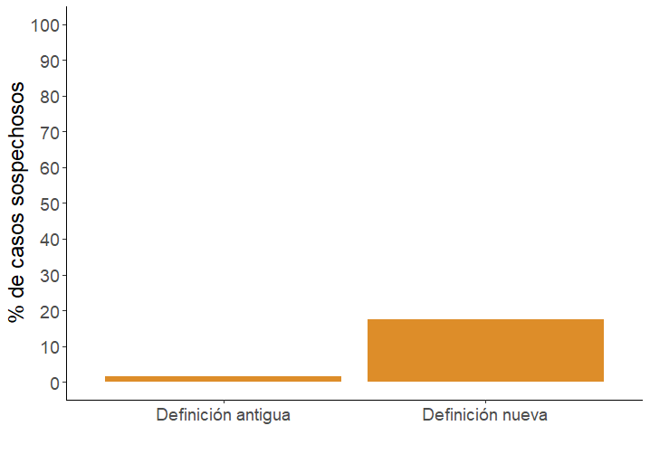

Figura 1. Porcentaje de casos sospechosos según definición antigua y nueva (MOVID-19, Ola 2, n = 29.730)

La Organización Mundial de la Salud recomienda mantener la distancia física y quedarse en casa para disminuir la propagación de la enfermedad. En MOVID-19 hemos pedido a los participantes reportar el número de días de la última semana en que han salido de sus casas. Los resultados son alentadores: La gran mayoría de los participantes de este estudio ha salido poco de sus hogares (un día o menos a la semana, ver Figura 2). Incluso quienes deben salir por causas como el trabajo, compras o trámite, lo hacen en promedio menos de dos días a la semana. Esto demuestra que en las semanas previas la gran mayoría de los participantes MOVID-19 ha asumido responsablemente el autocuidado y el cuidado de otros. Dado que hemos visto un incremento de casos durante la última semana, es importante no relajar estos esfuerzos. Los invitamos a seguir cuidándose y cuidando a los demás, y a registrar su información periódicamente para contar con información que será sumamente valiosa para enfrentar todas y todos esta pandemia.

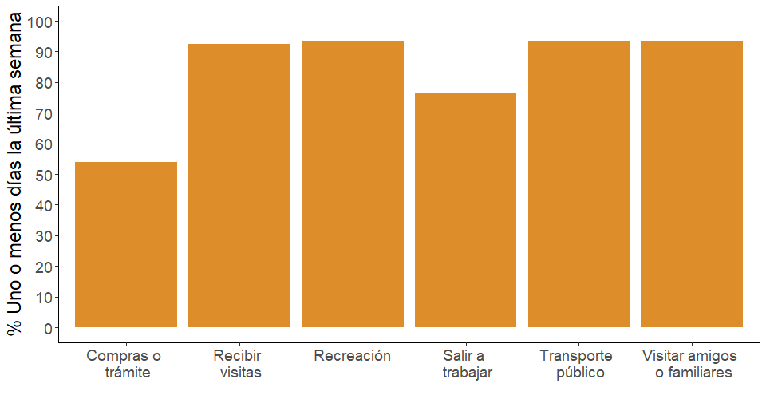

Figura 2. Porcentaje de participantes que han realizado actividades uno o menos días a la semana (MOVID-19, Ola 2, n = 29.730)

### Cómo seguir aportando

Para continuar este gran esfuerzo, necesitamos de su colaboración:

- Siga completando de manera semanal su situación actual de salud. Esta información es importante, sin importar si su situación ha cambiado o si se mantiene igual. Cuando sea el momento de contestar, le enviaremos un correo electrónico con una invitación dedicada para Ud.
- Invite a más personas a participar. Comparta el vínculo contesta.movid19.cl en su comunidad, lugar de trabajo o estudio, a sus amigos o familia. Necesitamos llegar a la mayor cantidad de personas mayores de 18 años que viven en Chile.
- ¡Siga manteniendo distancia física y quédandose en casa lo más posible!

### ¡Esta pandemia la enfrentamos entre todas y todos!

Gracias por seguir participando en MOVID-19,

**Equipo MOVID-19**  
**Colegio Médico de Chile**  
**Universidad de Chile**  
**encuestacovid@uchile.cl**